# BUSN 41201 Final Project

### Hierarchical Clustering

Hierarchical clustering is a clustering algorithm that aims to create a hierarchical structure of clusters based on the similarity or dissimilarity between data points. The algorithm starts by considering each data point as an individual cluster and then progressively merges similar clusters together until a single cluster containing all data points is formed. The procedure can be explained in the following steps:

1. Data representation: Begin with a dataset consisting of $n$ data points that you want to cluster. Determine the appropriate representation of the data, such as a distance matrix or a matrix of pairwise similarities/dissimilarities between data points.
2. Distance/similarity calculation: Calculate the distance or similarity between each pair of data points in the dataset. Common distance measures include Euclidean distance, Manhattan distance, or correlation distance.
3. Cluster initialization: Treat each data point as an individual cluster initially. Each data point is considered as a separate cluster at the start of the algorithm.
4. Cluster merging: Iteratively merge clusters based on their similarity or distance. The two most similar (or closest) clusters are merged at each step to form a larger cluster. The specific method for measuring similarity and determining which clusters to merge depends on the chosen linkage criterion.
5. Linkage criteria: Different linkage criteria define the similarity or distance between clusters and guide the merging process. Some common linkage criteria include:
- Single linkage: The similarity between two clusters is defined as the minimum distance between any two data points, one from each cluster.
- Complete linkage: The similarity between two clusters is defined as the maximum distance between any two data points, one from each cluster.
- Average linkage: The similarity between two clusters is defined as the average distance between all pairs of data points, one from each cluster.
6. Determining the number of clusters: At any point during the merging process, you can cut the dendrogram at a certain level to obtain a desired number of clusters. The height or dissimilarity level at which the dendrogram is cut determines the number of resulting clusters.

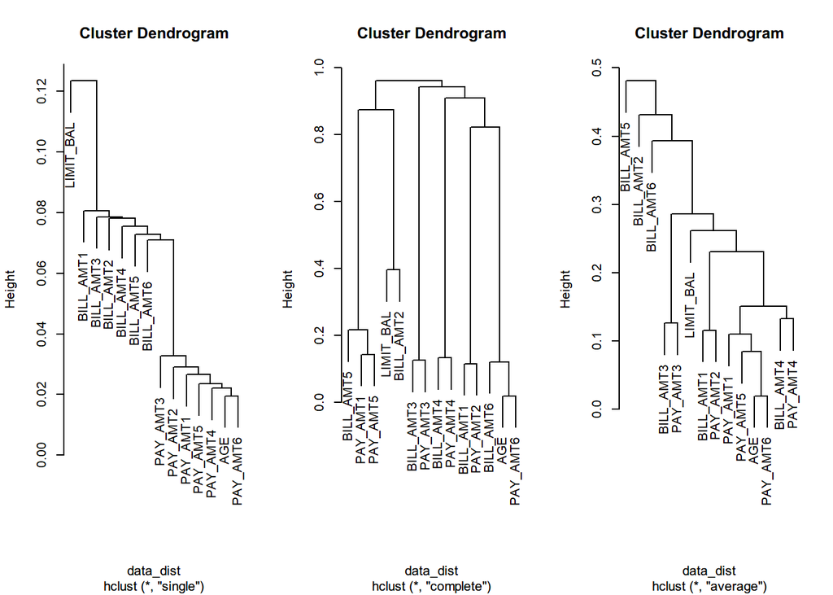

```r
# variables clustering
# only use numerical data to do hierarchical clustering
# use correlation as similarity measure
# variable clustering
data_hc = data[,-c(2,3,4,6,7,8,9,10,11,24)]
cor_data = cor(data_hc)
data_dist = as.dist(cor_data)
Msingle = hclust(data_dist, method = "single")
Mcomplete = hclust(data_dist, method = "complete")
Maverage = hclust(data_dist, method = "average")
par(mfrow = c(1, 3))
plot(Msingle)
plot(Mcomplete)
plot(Maverage)
```

By the three different linkages, we can obtain some interesting findings.

1. Single Linkage: We can see that `PAY` and `BILL` two different categorical variables are clustering together. And, `Age` is the most closed to the most far payment `PAY_AMT6`.
2. Complete Linkage: It prefers to cluster some period of `PAY` and `BILL` together.
3. Average Linkage: The pattern is unclear. But, we still have that `Age` is the most closed to the most far payment `PAY_AMT6`.

By clustering variables, we can identify groups or clusters of variables that are related to each other. Variables within the same cluster often have similar behavior or share common underlying factors. This grouping can help in understanding the structure and organization of the dataset, revealing hidden patterns or relationships.

Next, we want to cluster by observations, but our observations is too large, that we need to reach from other approaches. I choose to randomly sample $500$ observations from our dataset, and trying to find the pattern in the sample.

```r
# Subset the data by randomly selecting 500 observations
subset_data <- data_hc[sample(nrow(data_hc), 500), ]

# Perform hierarchical clustering on the subset data
hc <- hclust(dist(subset_data))

# Summary of clustered sample observation
cluster_labels <- cutree(hc, k = 3)
subset_data$cluster_labels <- cluster_labels
summary(subset_data[subset_data$cluster_labels==1,])
```

```
##    LIMIT_BAL           AGE          BILL_AMT1        BILL_AMT2
##  Min.   : 10000   Min.   :21.00   Min.   :  -227   Min.   : -2522
##  1st Qu.: 50000   1st Qu.:27.00   1st Qu.:  8948   1st Qu.: 10124
##  Median :110000   Median :32.00   Median : 30372   Median : 28746
##  Mean   :149287   Mean   :34.01   Mean   : 45315   Mean   : 43504
##  3rd Qu.:210000   3rd Qu.:40.00   3rd Qu.: 67069   3rd Qu.: 59617
##  Max.   :650000   Max.   :69.00   Max.   :231181   Max.   :192558
##    BILL_AMT3        BILL_AMT4        BILL_AMT5        BILL_AMT6
##  Min.   :  -649   Min.   :-81334   Min.   :   -10   Min.   :  -177
##  1st Qu.:  8942   1st Qu.:  9945   1st Qu.:  8661   1st Qu.:  6632
##  Median : 27026   Median : 25199   Median : 22707   Median : 22535
##  Mean   : 42265   Mean   : 38734   Mean   : 36637   Mean   : 35872
##  3rd Qu.: 59565   3rd Qu.: 54943   3rd Qu.: 51251   3rd Qu.: 49105
##  Max.   :196537   Max.   :165797   Max.   :185994   Max.   :188730
##     PAY_AMT1         PAY_AMT2         PAY_AMT3         PAY_AMT4
##  Min.   :     0   Min.   :     0   Min.   :     0   Min.   :     0
##  1st Qu.:  1441   1st Qu.:  1144   1st Qu.:  1000   1st Qu.:   700
##  Median :  2315   Median :  2000   Median :  1955   Median :  1683
##  Mean   :  5145   Mean   :  5044   Mean   :  4813   Mean   :  4651
##  3rd Qu.:  5000   3rd Qu.:  4672   3rd Qu.:  4566   3rd Qu.:  3735
##  Max.   :164163   Max.   :120377   Max.   :130447   Max.   :331788
##     PAY_AMT5         PAY_AMT6      cluster_labels
##  Min.   :     0   Min.   :     0   Min.   :1
##  1st Qu.:   658   1st Qu.:   515   1st Qu.:1
##  Median :  1502   Median :  1511   Median :1
##  Mean   :  4428   Mean   :  4098   Mean   :1
##  3rd Qu.:  3200   3rd Qu.:  3354   3rd Qu.:1
##  Max.   :155681   Max.   :216338   Max.   :1
```

```r
summary(subset_data[subset_data$cluster_labels==2,])
```

```
##    LIMIT_BAL           AGE          BILL_AMT1        BILL_AMT2
##  Min.   :200000   Min.   :25.00   Min.   :153798   Min.   :158903
##  1st Qu.:220000   1st Qu.:32.00   1st Qu.:200318   1st Qu.:197620
##  Median :265000   Median :35.00   Median :223946   Median :211147
##  Mean   :288889   Mean   :38.58   Mean   :239341   Mean   :228910
##  3rd Qu.:340000   3rd Qu.:43.25   3rd Qu.:275983   3rd Qu.:259119
##  Max.   :610000   Max.   :75.00   Max.   :389335   Max.   :388150
##    BILL_AMT3        BILL_AMT4        BILL_AMT5        BILL_AMT6
##  Min.   :160658   Min.   :152525   Min.   :125412   Min.   : 19959
##  1st Qu.:191577   1st Qu.:188817   1st Qu.:181218   1st Qu.:170258
##  Median :214147   Median :204282   Median :193640   Median :194066
##  Mean   :230333   Mean   :219099   Mean   :203629   Mean   :191896
##  3rd Qu.:257011   3rd Qu.:232951   3rd Qu.:212398   3rd Qu.:213753
##  Max.   :415700   Max.   :399343   Max.   :402432   Max.   :409912
##     PAY_AMT1        PAY_AMT2        PAY_AMT3         PAY_AMT4
##  Min.   :    0   Min.   :    0   Min.   :  4007   Min.   :   52
##  1st Qu.: 7912   1st Qu.: 7060   1st Qu.:  7075   1st Qu.: 6500
##  Median : 9276   Median : 8603   Median :  8682   Median : 7115
##  Mean   : 9454   Mean   : 8331   Mean   : 15607   Mean   : 7334
##  3rd Qu.:10650   3rd Qu.:10012   3rd Qu.: 10190   3rd Qu.: 8052
##  Max.   :20000   Max.   :14100   Max.   :231888   Max.   :17100
##     PAY_AMT5         PAY_AMT6     cluster_labels
##  Min.   :     0   Min.   :    0   Min.   :2
##  1st Qu.:  5990   1st Qu.: 5490   1st Qu.:2
##  Median :  7125   Median : 7000   Median :2
##  Mean   : 13333   Mean   : 6671   Mean   :2
##  3rd Qu.:  7879   3rd Qu.: 7740   3rd Qu.:2
##  Max.   :223765   Max.   :11500   Max.   :2
```

```r
summary(subset_data[subset_data$cluster_labels==3,])
```

```
##    LIMIT_BAL           AGE       BILL_AMT1        BILL_AMT2
##  Min.   :550000   Min.   :35   Min.   :539092   Min.   :552234
##  1st Qu.:550000   1st Qu.:35   1st Qu.:539092   1st Qu.:552234
##  Median :550000   Median :35   Median :539092   Median :552234
##  Mean   :550000   Mean   :35   Mean   :539092   Mean   :552234
##  3rd Qu.:550000   3rd Qu.:35   3rd Qu.:539092   3rd Qu.:552234
##  Max.   :550000   Max.   :35   Max.   :539092   Max.   :552234
##    BILL_AMT3        BILL_AMT4        BILL_AMT5        BILL_AMT6
##  Min.   :565550   Min.   :572805   Min.   :823540   Min.   :501370
##  1st Qu.:565550   1st Qu.:572805   1st Qu.:823540   1st Qu.:501370
##  Median :565550   Median :572805   Median :823540   Median :501370
##  Mean   :565550   Mean   :572805   Mean   :823540   Mean   :501370
##  3rd Qu.:565550   3rd Qu.:572805   3rd Qu.:823540   3rd Qu.:501370
##  Max.   :565550   Max.   :572805   Max.   :823540   Max.   :501370
##     PAY_AMT1        PAY_AMT2        PAY_AMT3        PAY_AMT4    PAY_AMT5
##  Min.   :23000   Min.   :23000   Min.   :18000   Min.   :0   Min.   :18373
##  1st Qu.:23000   1st Qu.:23000   1st Qu.:18000   1st Qu.:0   1st Qu.:18373
##  Median :23000   Median :23000   Median :18000   Median :0   Median :18373
##  Mean   :23000   Mean   :23000   Mean   :18000   Mean   :0   Mean   :18373
##  3rd Qu.:23000   3rd Qu.:23000   3rd Qu.:18000   3rd Qu.:0   3rd Qu.:18373
##  Max.   :23000   Max.   :23000   Max.   :18000   Max.   :0   Max.   :18373
##     PAY_AMT6     cluster_labels
##  Min.   :18159   Min.   :3
##  1st Qu.:18159   1st Qu.:3
##  Median :18159   Median :3
##  Mean   :18159   Mean   :3
##  3rd Qu.:18159   3rd Qu.:3
##  Max.   :18159   Max.   :3
```

Hierarchical clustering allows for a bottom-up approach, starting with individual data points and iteratively merging clusters based on similarity or distance. The resulting dendrogram provides a visual representation of the cluster hierarchy, and by cutting the dendrogram at an appropriate level, you can obtain clusters at different granularities. This algorithm is flexible and can handle various types of data and distance/similarity measures, making it widely used in exploratory data analysis and visualization.

### Gaussian Mixture Models (GMM)

Gaussian Mixture Models (GMM) is a probabilistic clustering algorithm that assumes the underlying data distribution is a mixture of Gaussian distributions. GMM clustering aims to model the data as a collection of Gaussian components, each representing a cluster.

Here’s a step-by-step explanation of how Gaussian Mixture Models clustering works:

1. Initialize the parameters of Gaussian components, including means, covariances, and mixing coefficients.
2. Use the Expectation-Maximization (EM) algorithm to iteratively estimate the parameters and update cluster assignments.
3. Repeat the E-step: Calculate the posterior probabilities (responsibilities) of data points belonging to each cluster.
4. Repeat the M-step: Update the parameters of Gaussian components based on the weighted contributions of data points.
5. Iterate steps 3 and 4 until convergence is reached.
6. Assign each data point to the cluster with the highest posterior probability.
7. Determine the optimal number of clusters using model selection criteria.

But now we can use package `mclust` to avoid probability calculation. I find three clusters in this method.

```r
# Perform GMM clustering
library(mclust)
data_mc = data
gmm_model <- Mclust(data_mc[, -24], G = 3)
summary(gmm_model)
```

```
## ----------------------------------------------------
## Gaussian finite mixture model fitted by EM algorithm
## ----------------------------------------------------
##
## Mclust VEV (ellipsoidal, equal shape) model with 3 components:
##
##  log-likelihood     n  df      BIC      ICL
##        -3472243 23150 855 -6953079 -6953507
##
## Clustering table:
##     1     2     3
## 10230 10860  2060
```

```r
# Retrieve the cluster assignments
cluster_labels <- gmm_model$classification

# Summary of clustered sample observation
data_mc$cluster_labels <- cluster_labels
summary(data_mc[data_mc$cluster_labels==1,])
```

```
##    LIMIT_BAL          SEX             EDUCATION       MARRIAGE
##  Min.   : 10000   Male  :4028   Grad.School:3135   Married:4514
##  1st Qu.: 50000   Female:6202   High.School:1816   Other  : 123
##  Median :110000                 Other      :  33   Single :5593
##  Mean   :140336                 University :5246
##  3rd Qu.:200000
##  Max.   :710000
##
##       AGE            PAY_0          PAY_2           PAY_3           PAY_4
##  Min.   :21.00   0      :9602   0      :10230   0      :10230   0      :10230
##  1st Qu.:27.00   2      : 453   1      :    0   1      :    0   1      :    0
##  Median :33.00   1      : 175   2      :    0   2      :    0   2      :    0
##  Mean   :35.04   3      :   0   3      :    0   3      :    0   3      :    0
##  3rd Qu.:41.00   4      :   0   4      :    0   4      :    0   4      :    0
##  Max.   :73.00   5      :   0   5      :    0   5      :    0   5      :    0
##                  (Other):   0   (Other):    0   (Other):    0   (Other):    0
##      PAY_5           PAY_6         BILL_AMT1        BILL_AMT2
##  0      :10230   0      :10230   Min.   : -2000   Min.   : -2604
##  1      :    0   1      :    0   1st Qu.:  8215   1st Qu.:  7968
##  2      :    0   2      :    0   Median : 32835   Median : 30367
##  3      :    0   3      :    0   Mean   : 48739   Mean   : 47446
##  4      :    0   4      :    0   3rd Qu.: 70039   3rd Qu.: 67887
##  5      :    0   5      :    0   Max.   :311013   Max.   :305633
##  (Other):    0   (Other):    0
##    BILL_AMT3        BILL_AMT4        BILL_AMT5        BILL_AMT6
##  Min.   : -1404   Min.   : -1469   Min.   : -1889   Min.   : -8808
##  1st Qu.:  8033   1st Qu.:  7501   1st Qu.:  6482   1st Qu.:  4764
##  Median : 28601   Median : 25352   Median : 21361   Median : 20145
##  Mean   : 45877   Mean   : 42707   Mean   : 40242   Mean   : 39322
##  3rd Qu.: 65466   3rd Qu.: 59507   3rd Qu.: 55505   3rd Qu.: 54284
##  Max.   :301181   Max.   :303398   Max.   :289602   Max.   :294383
##
##     PAY_AMT1        PAY_AMT2        PAY_AMT3        PAY_AMT4
##  Min.   :    0   Min.   :    0   Min.   :    0   Min.   :    0
##  1st Qu.: 1500   1st Qu.: 1466   1st Qu.: 1006   1st Qu.:  795
##  Median : 2158   Median : 2112   Median : 2000   Median : 1700
##  Mean   : 3073   Mean   : 3028   Mean   : 2655   Mean   : 2357
##  3rd Qu.: 4008   3rd Qu.: 4000   3rd Qu.: 3600   3rd Qu.: 3204
##  Max.   :16923   Max.   :16020   Max.   :15934   Max.   :13000
##
##     PAY_AMT5        PAY_AMT6     default    cluster_labels
##  Min.   :    0   Min.   :    0   No :8751   Min.   :1
##  1st Qu.:  800   1st Qu.:  652   Yes:1479   1st Qu.:1
##  Median : 1802   Median : 1632              Median :1
##  Mean   : 2464   Mean   : 2391              Mean   :1
##  3rd Qu.: 3480   3rd Qu.: 3350              3rd Qu.:1
##  Max.   :16000   Max.   :18000              Max.   :1
##
```

```r
summary(data_mc[data_mc$cluster_labels==2,])
```

```
##    LIMIT_BAL          SEX             EDUCATION       MARRIAGE
##  Min.   : 10000   Male  :4504   Grad.School:3550   Married:4897
##  1st Qu.: 50000   Female:6356   High.School:1924   Other  : 134
##  Median :105000                 Other      :  23   Single :5829
##  Mean   :149564                 University :5363
##  3rd Qu.:210000
##  Max.   :780000
##
##       AGE           PAY_0          PAY_2          PAY_3          PAY_4
##  Min.   :21.0   0      :6652   0      :6907   0      :7072   0      :7632
##  1st Qu.:28.0   2      :1936   2      :3514   2      :3438   2      :2905
##  Median :34.0   1      :1859   3      : 304   3      : 221   3      : 165
##  Mean   :35.3   3      : 295   4      :  85   4      :  62   4      :  66
##  3rd Qu.:41.0   4      :  65   7      :  19   7      :  25   7      :  56
##  Max.   :79.0   8      :  19   5      :  14   6      :  22   5      :  33
##                 (Other):  34   (Other):  17   (Other):  20   (Other):   3
##      PAY_5          PAY_6        BILL_AMT1        BILL_AMT2
##  0      :8091   0      :7958   Min.   : -9802   Min.   : -7334
##  2      :2447   2      :2614   1st Qu.: 10515   1st Qu.: 11272
##  3      : 170   3      : 170   Median : 30720   Median : 30328
##  4      :  79   4      :  47   Mean   : 63966   Mean   : 62005
##  7      :  55   7      :  46   3rd Qu.: 82965   3rd Qu.: 79250
##  5      :  15   6      :  14   Max.   :608594   Max.   :624475
##  (Other):   3   (Other):  11
##    BILL_AMT3        BILL_AMT4        BILL_AMT5        BILL_AMT6
##  Min.   : -9032   Min.   :-27490   Min.   :-28335   Min.   :-16586
##  1st Qu.: 11689   1st Qu.: 11425   1st Qu.: 10450   1st Qu.:  9359
##  Median : 29257   Median : 27759   Median : 26022   Median : 24750
##  Mean   : 59117   Mean   : 54684   Mean   : 51067   Mean   : 49270
##  3rd Qu.: 74055   3rd Qu.: 67604   3rd Qu.: 60644   3rd Qu.: 57513
##  Max.   :632041   Max.   :569034   Max.   :551702   Max.   :568638
##
##     PAY_AMT1        PAY_AMT2        PAY_AMT3        PAY_AMT4
##  Min.   :    0   Min.   :    0   Min.   :    0   Min.   :    0.0
##  1st Qu.: 1000   1st Qu.: 1000   1st Qu.:  656   1st Qu.:  515.8
##  Median : 2700   Median : 2500   Median : 2000   Median : 2000.0
##  Mean   : 5083   Mean   : 5027   Mean   : 4582   Mean   : 4456.9
##  3rd Qu.: 6347   3rd Qu.: 6087   3rd Qu.: 5385   3rd Qu.: 5039.2
##  Max.   :52129   Max.   :57425   Max.   :53198   Max.   :60030.0
##
##     PAY_AMT5        PAY_AMT6     default    cluster_labels
##  Min.   :    0   Min.   :    0   No :7262   Min.   :2
##  1st Qu.:  487   1st Qu.:  460   Yes:3598   1st Qu.:2
##  Median : 1940   Median : 1846              Median :2
##  Mean   : 4115   Mean   : 3914              Mean   :2
##  3rd Qu.: 5000   3rd Qu.: 4884              3rd Qu.:2
##  Max.   :52000   Max.   :48061              Max.   :2
##
```

```r
summary(data_mc[data_mc$cluster_labels==3,])
```

```
##    LIMIT_BAL           SEX             EDUCATION      MARRIAGE
##  Min.   :  10000   Male  : 924   Grad.School:879   Married: 943
##  1st Qu.: 150000   Female:1136   High.School:255   Other  :  12
##  Median : 260000                 Other      : 16   Single :1105
##  Mean   : 270714                 University :910
##  3rd Qu.: 360000
##  Max.   :1000000
##
##       AGE            PAY_0          PAY_2          PAY_3          PAY_4
##  Min.   :22.00   0      :1796   0      :1889   0      :1909   0      :1946
##  1st Qu.:29.00   1      : 135   2      : 126   2      : 117   2      :  87
##  Median :34.00   2      : 104   3      :  13   4      :  14   3      :  14
##  Mean   :35.96   3      :   9   5      :  11   3      :   9   4      :   3
##  3rd Qu.:41.00   4      :   9   1      :   8   1      :   3   1      :   2
##  Max.   :67.00   5      :   4   4      :   8   5      :   3   5      :   2
##                  (Other):   3   (Other):   5   (Other):   5   (Other):   6
##      PAY_5          PAY_6        BILL_AMT1         BILL_AMT2
##  0      :1973   0      :1971   Min.   :-165580   Min.   :-67526
##  2      :  71   2      :  72   1st Qu.:  14569   1st Qu.: 18575
##  3      :   5   3      :   6   Median :  64402   Median : 70209
##  4      :   4   6      :   5   Mean   : 109596   Mean   :108174
##  7      :   3   4      :   2   3rd Qu.: 167375   3rd Qu.:159496
##  5      :   2   5      :   2   Max.   : 964511   Max.   :983931
##  (Other):   2   (Other):   2
##    BILL_AMT3         BILL_AMT4         BILL_AMT5        BILL_AMT6
##  Min.   :-157264   Min.   :-170000   Min.   :-81334   Min.   :-339603
##  1st Qu.:  21250   1st Qu.:  23775   1st Qu.: 22357   1st Qu.:  19199
##  Median :  70069   Median :  69697   Median : 64631   Median :  58993
##  Mean   : 105084   Mean   :  98351   Mean   : 90574   Mean   :  83599
##  3rd Qu.: 151504   3rd Qu.: 136268   3rd Qu.:128245   3rd Qu.: 120788
##  Max.   : 693131   Max.   : 891586   Max.   :927171   Max.   : 961664
##
##     PAY_AMT1         PAY_AMT2          PAY_AMT3         PAY_AMT4
##  Min.   :     0   Min.   :      0   Min.   :     0   Min.   :     0
##  1st Qu.:  3000   1st Qu.:   2896   1st Qu.:  2011   1st Qu.:  2000
##  Median :  8000   Median :   7000   Median :  5670   Median :  5000
##  Mean   : 26206   Mean   :  27228   Mean   : 25168   Mean   : 21991
##  3rd Qu.: 25043   3rd Qu.:  21014   3rd Qu.: 20002   3rd Qu.: 17000
##  Max.   :873552   Max.   :1227082   Max.   :896040   Max.   :621000
##
##     PAY_AMT5         PAY_AMT6      default    cluster_labels
##  Min.   :     0   Min.   :     0   No :1775   Min.   :3
##  1st Qu.:  2004   1st Qu.:  2500   Yes: 285   1st Qu.:3
##  Median :  5034   Median :  5730              Median :3
##  Mean   : 22820   Mean   : 27445              Mean   :3
##  3rd Qu.: 20022   3rd Qu.: 30000              3rd Qu.:3
##  Max.   :426529   Max.   :528666              Max.   :3
##
```

[figure not shown]

```r
# Visualization
plot(gmm_model,what=c("density"))
```

## Machine Learning

### Decision Trees

### Random Forest

### Classification And Regression Trees (CART)

### Neural Network

```r
#n <- names(train_data)
#f <- as.formula(paste("default ~", paste(n[!n %in% "default"], collapse = " + ")))
#nn <- neuralnet(f,data=train,hidden=c(5,3),linear.output=T)
```

# Conclusion

# Potential Future Research

# Appendix